# Coursera Assignment

Gmatmarshall

September 11, 2016

## Loading and preprocessing the data

The following command uses R to download and unzip the data file and store the results in the variable activity.

```r
setwd("~/Coursera/Reproducible_Research")
download.file("https://d396qusza40orc.cloudfront.net/repdata%2Fdata%2Factivity.zip","activity.zip",method="curl")
unzip("activity.zip", "activity.csv")
activity <- read.csv("~/Coursera/Reproducible_Research/activity.csv")
```

The next command reoves the NA elements from the dataset and store the new data in the variable activityn

```r
activityn<-activity[!is.na(activity$steps),]
```

## The mean total number of steps taken per day

Now the total number of steps each day is computed and stored in the variable sumd.

```r
sumd<-with(activityn,tapply(steps,date,sum))
```

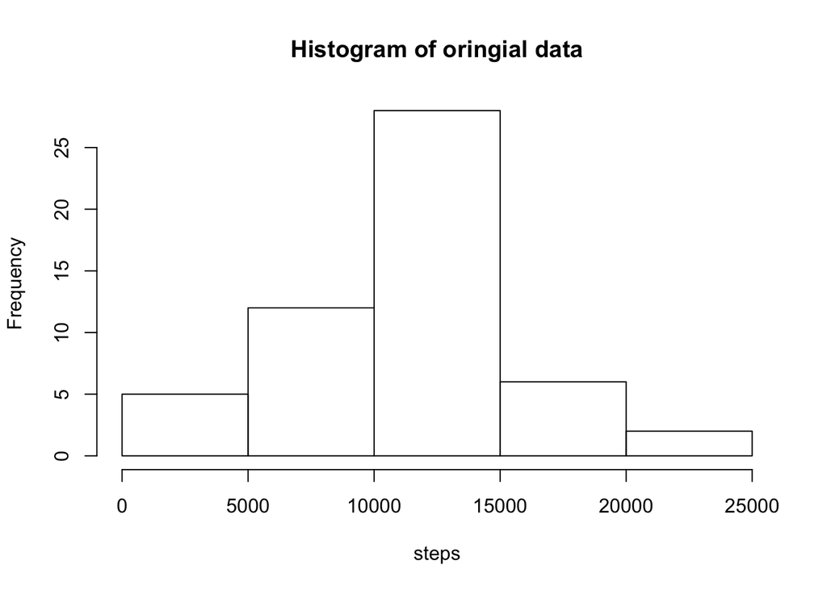

```r
hist(sumd, main="Histogram of oringial data",xlab="steps")
```

The mean and median of the total number of steps taken per day can easily be computed.

```r
mean(sumd,na.rm=TRUE)
```

```
## [1] 10766.19
```

```r
median(sumd,na.rm= TRUE)
```

```
## [1] 10765
```

## The average daily activity pattern

Using activityn variable (where the NAs have been removed) we compute the average across all days for particular intervals.

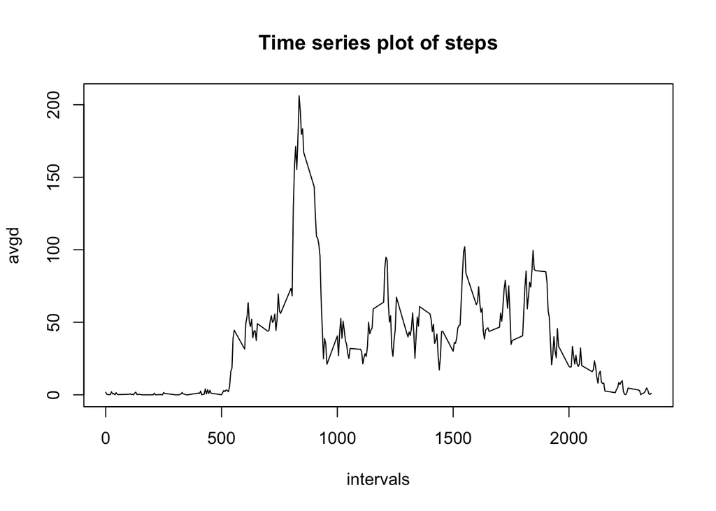

```r
avgd<- with(activityn,tapply(steps,interval,mean))
plot(avgd~as.integer(names(avgd)),type='l', main = "Time series plot of steps", xlab="intervals")
```

The interval that contains the maximum is

```r
avgd[avgd==max(avgd)]
```

```
##      835
## 206.1698
```

We see that interval 835 contains the highest number of steps.

## Imputing missing values

The code below will count the number of NAs (done by coercing the TRUE values to 1 and FALSE values to 0)

```r
sum(is.na(activity$steps))
```

```
## [1] 2304
```

Replace all the NA values with the mean and store it in variable activity2

```r
activity2<-activity
activity2$steps[is.na(activity$steps)]<-mean(activity$steps,na.rm=TRUE)
```

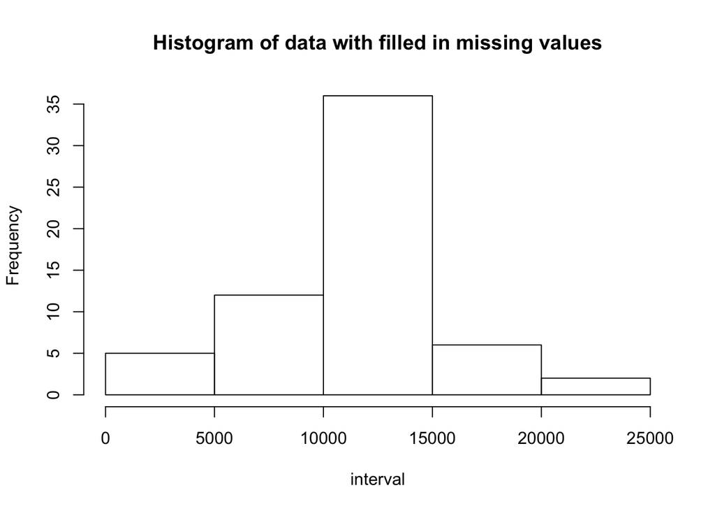

```r
sumd2<-with(activity2,tapply(steps,date,sum))
hist(sumd2, main="Histogram of data with filled in missing values", xlab="interval")
```

```r
mean(sumd2)
```

```
## [1] 10766.19
```

```r
median(sumd2)
```

```
## [1] 10766.19
```

Note these values do not change much from the original values. It will affect the standard deviation.

## Differences in activity patterns between weekdays and weekends?

The code below converts the dates in to the form of factors (weekdays and weekends)

```r
activity3<- activity2
 activity3$date<- as.Date(activity3$date)
 activity3$date<-weekdays(activity3$date)
activity3$date<-as.factor(activity3$date)
activity4<-activity3
levels(activity4$date)
```

```
## [1] "Friday"    "Monday"    "Saturday"  "Sunday"    "Thursday"  "Tuesday"
## [7] "Wednesday"
```

```r
levels(activity4$date) <- c("weekday","weekday","weekend","weekend","weekday","weekday","weekday")
```

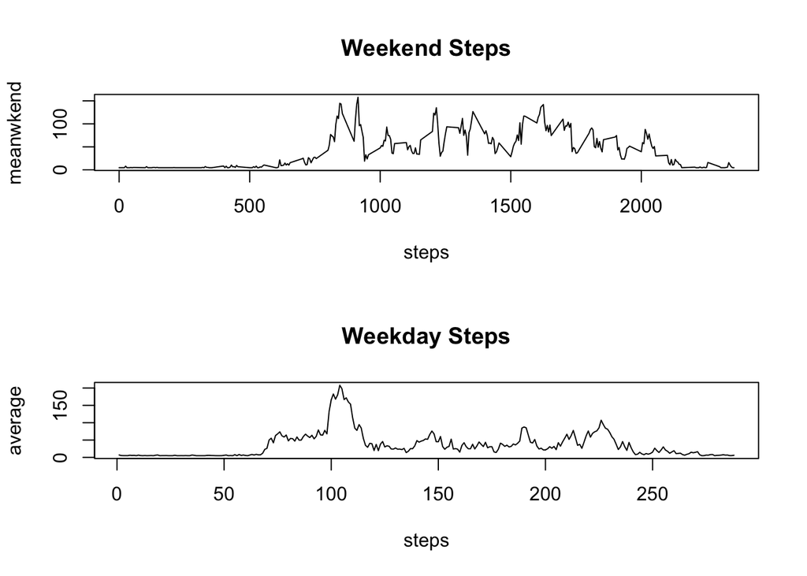

```r
wkday<-activity4[activity4$date=="weekday",]
wkend<-activity4[activity4$date=="weekend",]

meanwkday<-with(wkday,tapply(steps,interval,mean))
meanwkend<-with(wkend,tapply(steps,interval,mean))

par(mfrow=c(2,1))
plot(meanwkend~as.integer(names(meanwkend)),type='l', main="Weekend Steps",xlab="steps")
plot(meanwkday,type='l', main="Weekday Steps", xlab="steps",ylab="average")
```

We note that there is more activity on the weekend after the 1000th interval.